# Step3. DEGs and STEAM analysis

In this vignette we showcase how to use a MetaSpot/MetaBin approach with STEAM in a Visium HD dataset (16 µm), reducing sparseness and increasing power. Please note that some analysis steps have been pre-run in a separate vignette. We load Open Targets gene set data, selecting to include ranked genes with genetic associations to Bipolar disorder (MONDO_0004985).

We use a mouse coronal section from 10X: https://www.10xgenomics.com/datasets/visium-hd-cytassist-gene-expression-mouse-brain-fresh-frozen

# 1 Load libraries

```r
library(Seurat)
library(arrow)
library(dplyr)
library(STEAM)
library(ggplot2)
library(viridis)
library(readr)
```

# 2 Load data

```r
se <- readRDS(file="data/Visium_HD_mouse_coronal/metaspot_seurat_normalized.rds")
se
```

```
## An object of class Seurat
## 32164 features across 2232 samples within 2 assays
## Active assay: SCT (16082 features, 3000 variable features)
##  3 layers present: counts, data, scale.data
##  1 other assay present: RNA
```

Check number of Genes and UMIs per spatial cluster (MetaSpot/MetaBin data).

```r
se$cluster_anno <- factor(
  se$cluster_anno,
  levels = as.character(sort(as.numeric(levels(factor(se$cluster_anno)))))
)
```

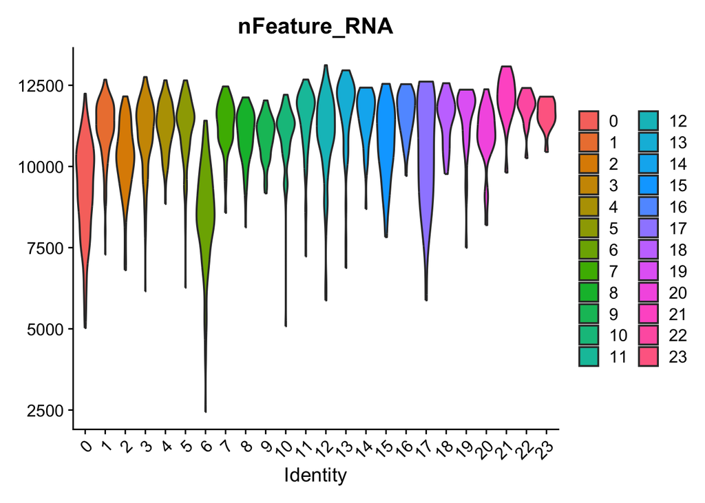

```r
VlnPlot(se, features = "nFeature_RNA", pt.size = 0, group.by = "cluster_anno")
```

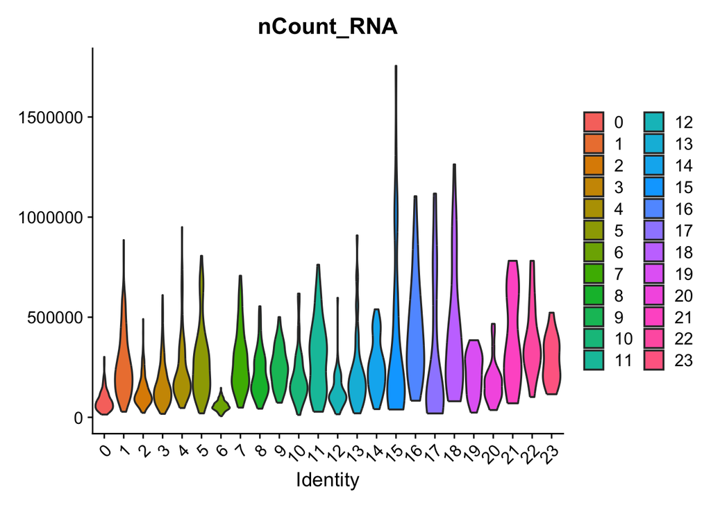

```r
VlnPlot(se, features = "nCount_RNA", pt.size = 0, group.by = "cluster_anno")
```

Check number of MetaSpots/MetaBins per spatial cluster.

```r
table(se$cluster_anno)
```

```
##
##   0   1   2   3   4   5   6   7   8   9  10  11  12  13  14  15  16  17  18  19
## 247 213 210 207 159 149 149 110 109  83  77  74  70  55  44  43  43  43  35  33
##  20  21  22  23
##  25  20  20  14
```

# 3 Prepare data for STEAM analysis

Load ranked gene lists (here from Open Targets).

```r
OpenTargets_BIP_Genetic_ <- as.character(t(read.table(file = "data/Visium_HD_mouse_coronal/OT-MONDO_0004985-associated-targets-5_15_2026-v26_03_BIP_genetic_mouse.csv")))
length(OpenTargets_BIP_Genetic_)
```

```
## [1] 825
```

IMPORTANT: Filter out genes not present in the Seurat object. Skipping this step makes the assumptions for the permutation statistics invalid.

```r
# Extract gene names from the Seurat object
gene_names <- rownames(se)
length(gene_names)
```

```
## [1] 16082
```

```r
# Check gene list size before filtering
length(OpenTargets_BIP_Genetic_)
```

```
## [1] 825
```

```r
# Remove genes not present in the Seurat object from the gene lists
OpenTargets_BIP_Genetic_ <- unique(OpenTargets_BIP_Genetic_[OpenTargets_BIP_Genetic_ %in% gene_names])

# Check gene list size after filtering
length(OpenTargets_BIP_Genetic_)
```

```
## [1] 764
```

Generate sliding window gene sets from gene lists. Select your choice of trait abbreviation (disease_abbr) and a gene list descriptive term (ot_gene_set_label). Here we select a window size of 50 genes, moving by 10 genes for each window.

```r
window_rank_list_BIP_Genetic <- generate_sliding_windows(OpenTargets_BIP_Genetic_, window_size = 50, step_size = 10, disease_abbr = "BIP", ot_gene_set_label = "Genetic")
```

Add gene sets to a list.

```r
all_gene_sets_OpenTargets <- list(OpenTargets_BIP_Genetic_=OpenTargets_BIP_Genetic_)
```

Merge all gene sets into one list.

```r
all_gene_sets <- all_gene_sets_OpenTargets
all_gene_sets <- append(all_gene_sets,window_rank_list_BIP_Genetic)
```

Calculate the average gene expression per gene set in the list and check the percentage of genes present in the Seurat object. It is important that all genes used are present in the Seurat object, otherwise the downstream statistic assumptions are invalid.

```r
score.mat <- matrix(data = NA, nrow = length(all_gene_sets), ncol = 1, dimnames = list(names(all_gene_sets), "% of genes present"))

for (i in 1:length(all_gene_sets)) {
  genes <- unlist(all_gene_sets[i])
  score.mat[i] <- mean(genes %in% rownames(se))
  se <- AddModuleScore(se,list(genes), ctrl = 100, name = list(names(all_gene_sets[i])))
}

score.mat*100
```

```
##                          % of genes present
## OpenTargets_BIP_Genetic_                100
## BIP_Genetic_Rank1_                      100
## BIP_Genetic_Rank2_                      100
## BIP_Genetic_Rank3_                      100
## BIP_Genetic_Rank4_                      100
## BIP_Genetic_Rank5_                      100
## BIP_Genetic_Rank6_                      100
## BIP_Genetic_Rank7_                      100
## BIP_Genetic_Rank8_                      100
## BIP_Genetic_Rank9_                      100
## BIP_Genetic_Rank10_                     100
## BIP_Genetic_Rank11_                     100
## BIP_Genetic_Rank12_                     100
## BIP_Genetic_Rank13_                     100
## BIP_Genetic_Rank14_                     100
## BIP_Genetic_Rank15_                     100
## BIP_Genetic_Rank16_                     100
## BIP_Genetic_Rank17_                     100
## BIP_Genetic_Rank18_                     100
## BIP_Genetic_Rank19_                     100
## BIP_Genetic_Rank20_                     100
## BIP_Genetic_Rank21_                     100
## BIP_Genetic_Rank22_                     100
## BIP_Genetic_Rank23_                     100
## BIP_Genetic_Rank24_                     100
## BIP_Genetic_Rank25_                     100
## BIP_Genetic_Rank26_                     100
## BIP_Genetic_Rank27_                     100
## BIP_Genetic_Rank28_                     100
## BIP_Genetic_Rank29_                     100
## BIP_Genetic_Rank30_                     100
## BIP_Genetic_Rank31_                     100
## BIP_Genetic_Rank32_                     100
## BIP_Genetic_Rank33_                     100
## BIP_Genetic_Rank34_                     100
## BIP_Genetic_Rank35_                     100
## BIP_Genetic_Rank36_                     100
## BIP_Genetic_Rank37_                     100
## BIP_Genetic_Rank38_                     100
```

[output cut: 19 more lines]

```
## BIP_Genetic_Rank58_                     100
## BIP_Genetic_Rank59_                     100
## BIP_Genetic_Rank60_                     100
## BIP_Genetic_Rank61_                     100
## BIP_Genetic_Rank62_                     100
## BIP_Genetic_Rank63_                     100
## BIP_Genetic_Rank64_                     100
## BIP_Genetic_Rank65_                     100
## BIP_Genetic_Rank66_                     100
## BIP_Genetic_Rank67_                     100
## BIP_Genetic_Rank68_                     100
## BIP_Genetic_Rank69_                     100
## BIP_Genetic_Rank70_                     100
## BIP_Genetic_Rank71_                     100
## BIP_Genetic_Rank72_                     100
```

Plot gene set scores for all trait genes and a few of the top sliding windows.

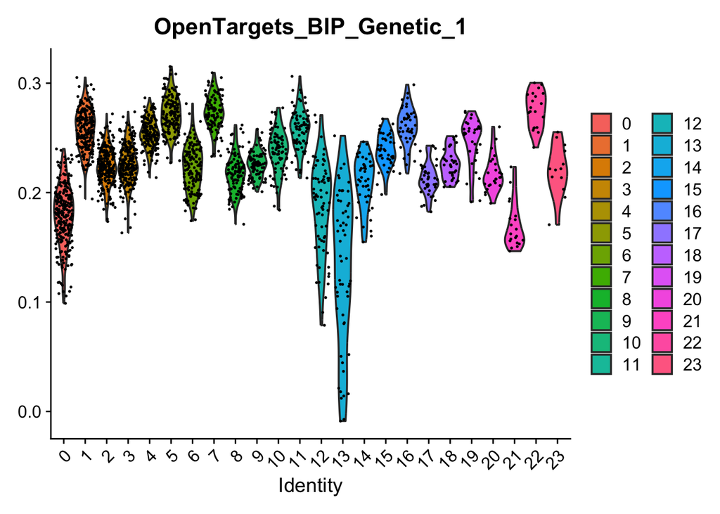

```r
VlnPlot(se, features = c("OpenTargets_BIP_Genetic_1"), ncol = 1, group.by = "cluster_anno")
```

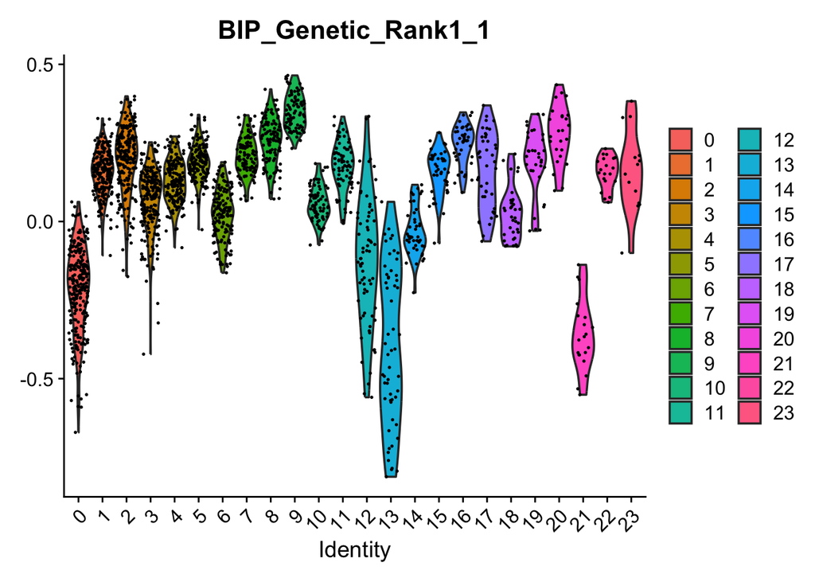

```r
VlnPlot(se, features = c("BIP_Genetic_Rank1_1"), ncol = 1, group.by = "cluster_anno")
```

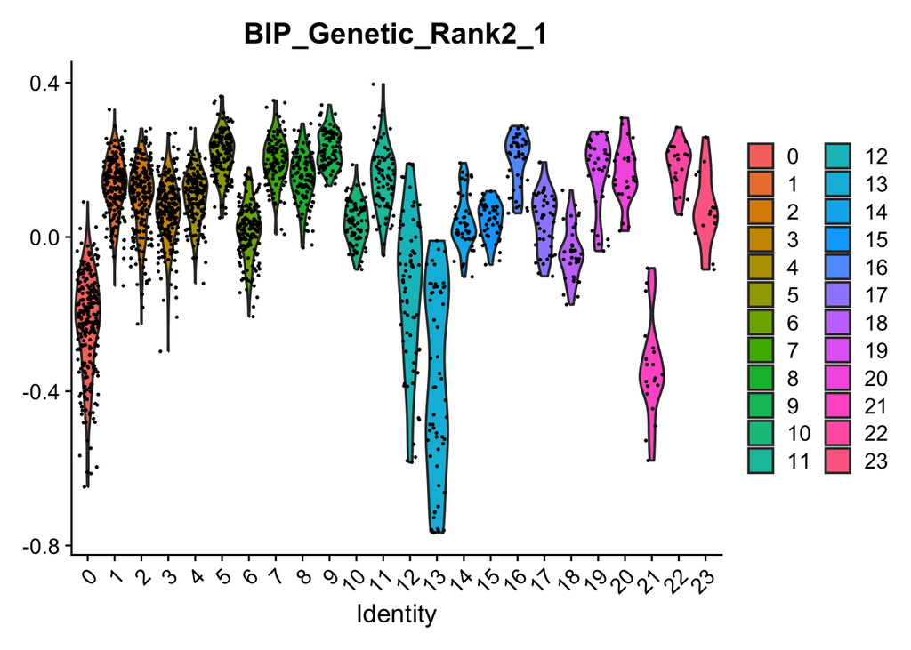

```r
VlnPlot(se, features = c("BIP_Genetic_Rank2_1"), ncol = 1, group.by = "cluster_anno")
```

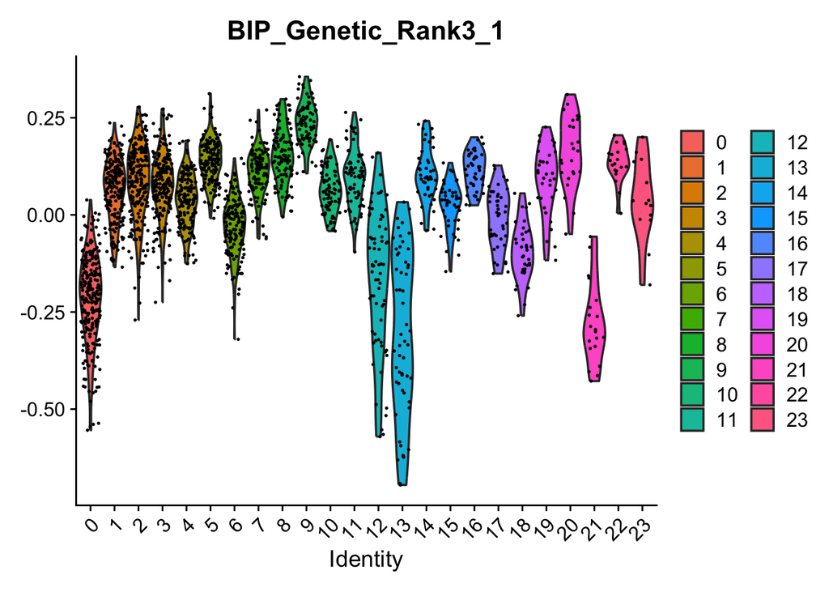

```r
VlnPlot(se, features = c("BIP_Genetic_Rank3_1"), ncol = 1, group.by = "cluster_anno")
```

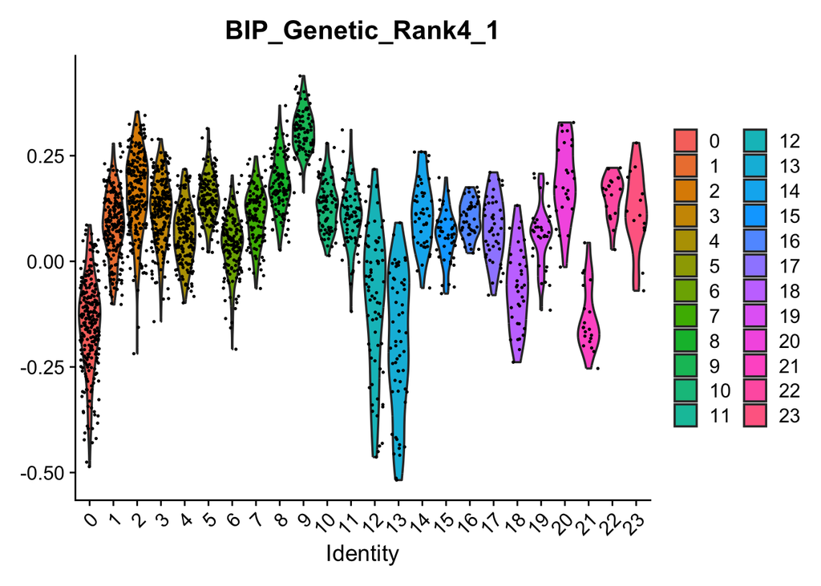

```r
VlnPlot(se, features = c("BIP_Genetic_Rank4_1"), ncol = 1, group.by = "cluster_anno")
```

Load the permutation matrix for your selected window size.

```r
perm_files <- c(
  "data/Visium_HD_mouse_coronal/perm.mat.par_p10000_g50.rds"
)

perm_matrices <- load_permutation_matrices(perm_files)
perm.mat.window.data <- as.data.frame(perm_matrices[[1]])

perm.mat.window.data[1:5,1:5]
```

```
##                    0            1            2           3            4
## Perm_nr1 -0.03232229  0.012066528 -0.007866593 -0.02839359 -0.031171115
## Perm_nr2 -0.05493832 -0.015624845 -0.027042843 -0.03106258 -0.012299639
## Perm_nr3 -0.03100417 -0.069230850  0.006055144 -0.05794741 -0.005509296
## Perm_nr4  0.01489332 -0.064301568 -0.028500918 -0.04666119 -0.009921522
## Perm_nr5 -0.06098865  0.002398074 -0.011932144  0.01577908 -0.036228243
```

# 4 Empirical selection of top genetic genes

Derive an empirical threshold for top genes of a ranked gene list by comparing the ranked window gene set signal to a null gene set of equal size.

```r
se$cluster_anno <- as.character(se$cluster_anno)

window_results.g <- window_rank_enrichment_analysis(
   se = se,
   perm.mat.window.data = perm.mat.window.data,
   window_rank_list = window_rank_list_BIP_Genetic,
   ot_gene_set_label = "Genetic",
   disease_abbr = "BIP",
   cluster_anno = "cluster_anno",
   imputation = "dynamic"
 )

head(window_results.g)
```

```
##                               cluster window median_score p_value        q05
## BIP_Genetic_cluster_0_Rank1 cluster_0      1  -0.19659961  0.9995 -0.1014342
## BIP_Genetic_cluster_0_Rank2 cluster_0      2  -0.20813044  0.9999 -0.1014342
## BIP_Genetic_cluster_0_Rank3 cluster_0      3  -0.20252652  0.9997 -0.1014342
## BIP_Genetic_cluster_0_Rank4 cluster_0      4  -0.13692920  0.9891 -0.1014342
## BIP_Genetic_cluster_0_Rank5 cluster_0      5  -0.07792158  0.8888 -0.1014342
## BIP_Genetic_cluster_0_Rank6 cluster_0      6  -0.05637983  0.8035 -0.1014342
##                                   q95 is_significant was_imputed
## BIP_Genetic_cluster_0_Rank1 0.1116792           TRUE       FALSE
## BIP_Genetic_cluster_0_Rank2 0.1116792           TRUE       FALSE
## BIP_Genetic_cluster_0_Rank3 0.1116792           TRUE       FALSE
## BIP_Genetic_cluster_0_Rank4 0.1116792           TRUE       FALSE
## BIP_Genetic_cluster_0_Rank5 0.1116792          FALSE       FALSE
## BIP_Genetic_cluster_0_Rank6 0.1116792          FALSE       FALSE
##                             imputation_type
## BIP_Genetic_cluster_0_Rank1            none
## BIP_Genetic_cluster_0_Rank2            none
## BIP_Genetic_cluster_0_Rank3            none
## BIP_Genetic_cluster_0_Rank4            none
## BIP_Genetic_cluster_0_Rank5            none
## BIP_Genetic_cluster_0_Rank6            none
```

Plot median scores for each window in each spatial cluster. Use these to identify sets of top genes.

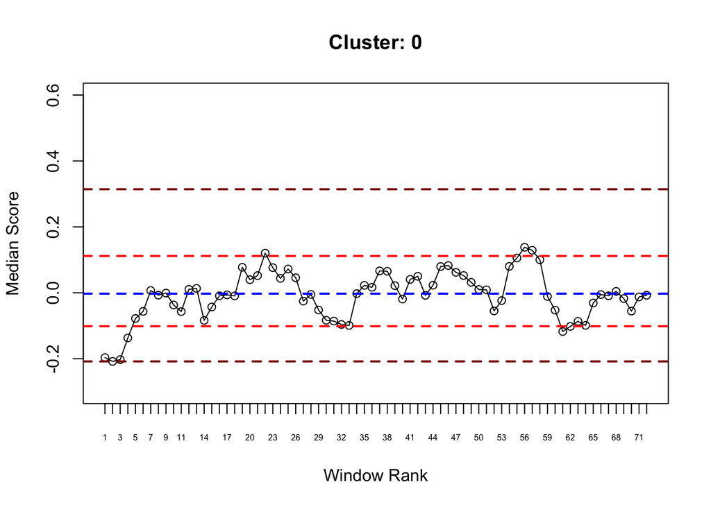

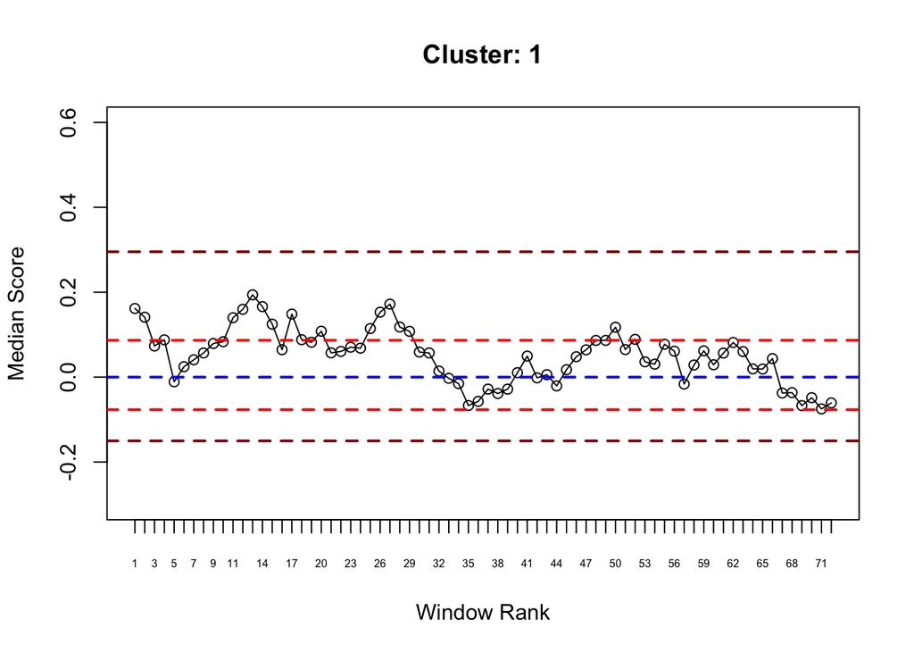

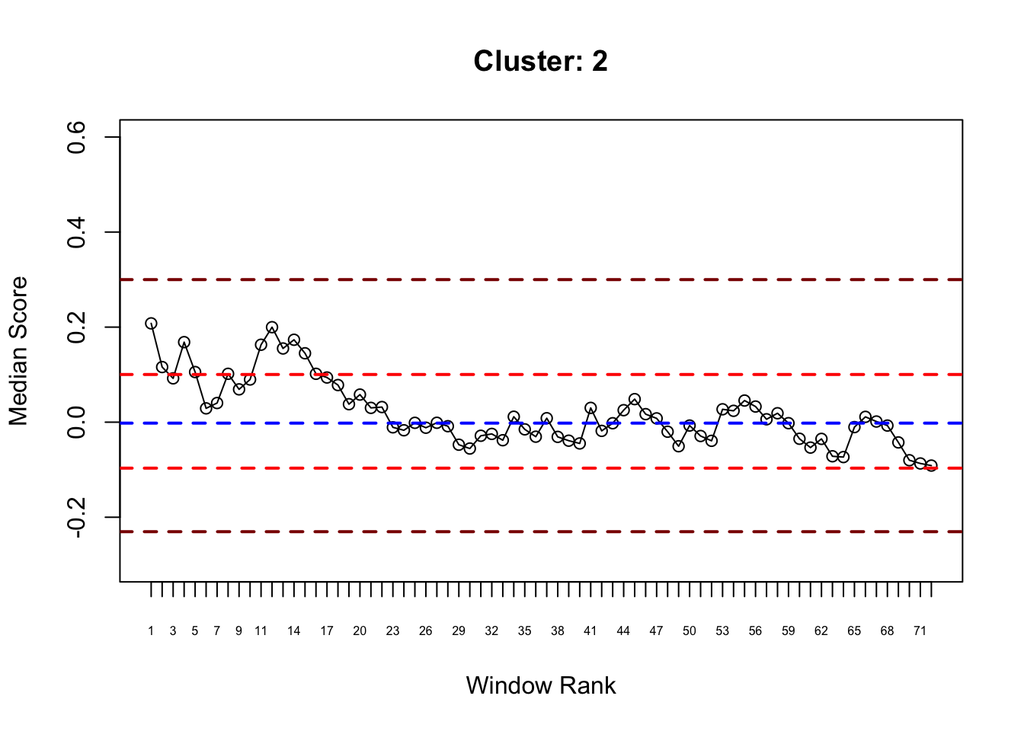

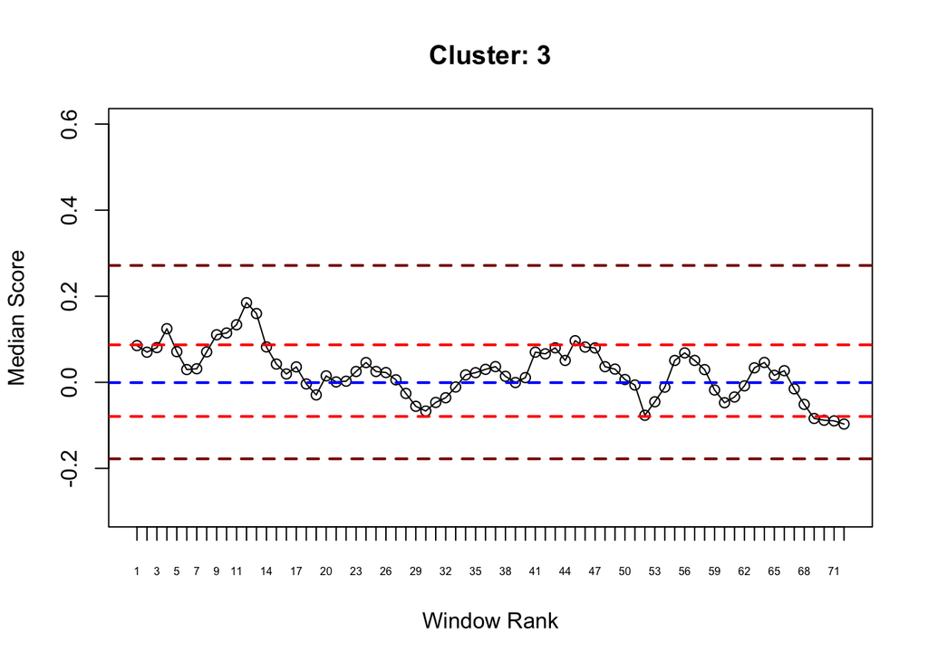

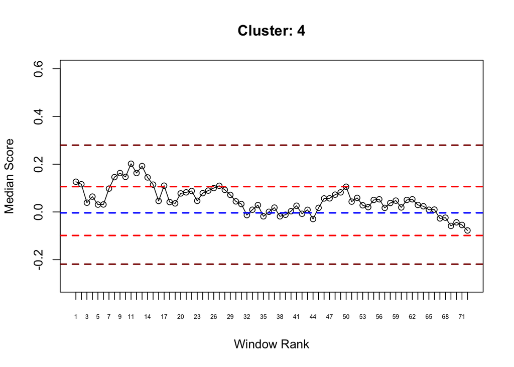

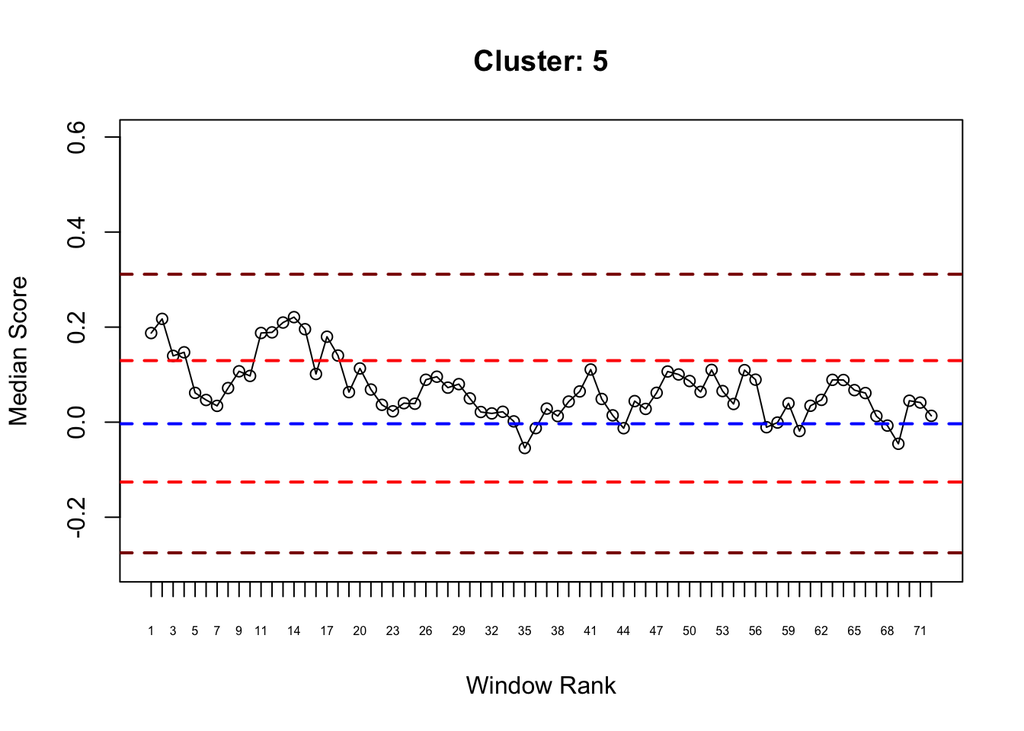

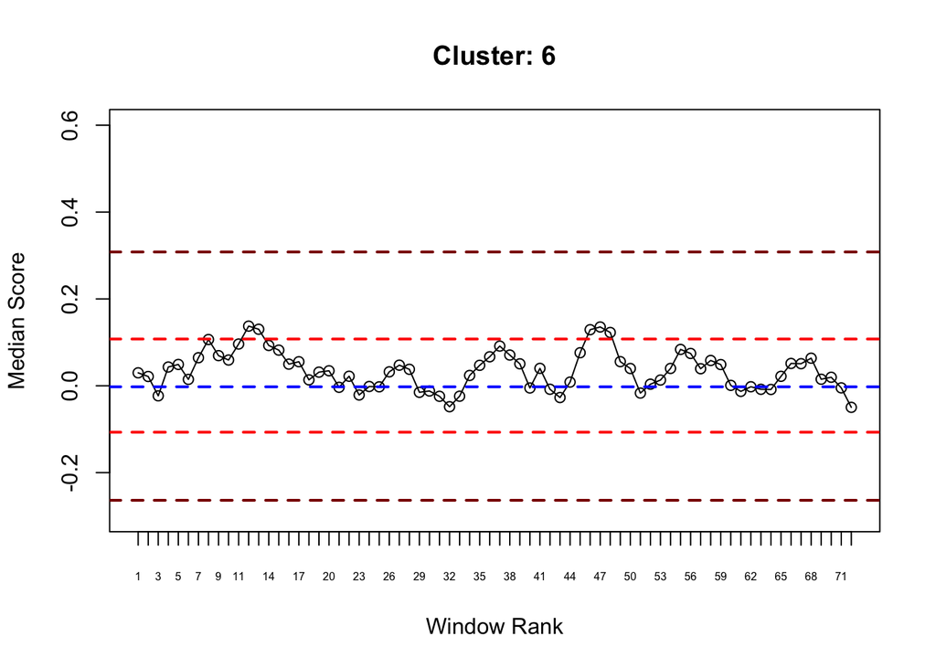

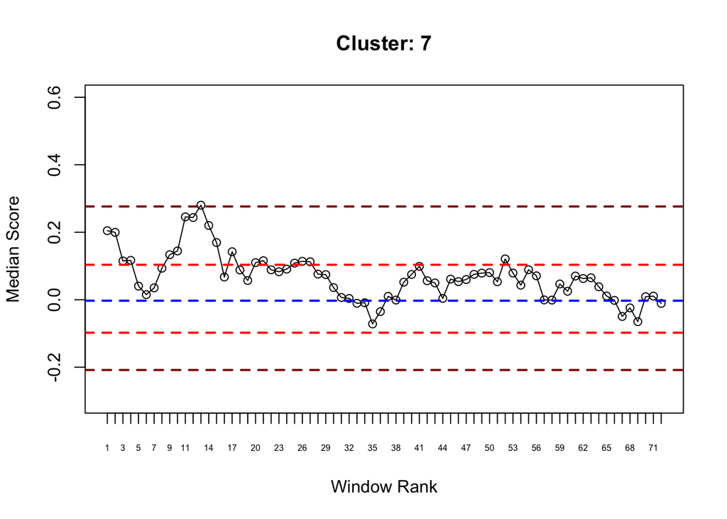

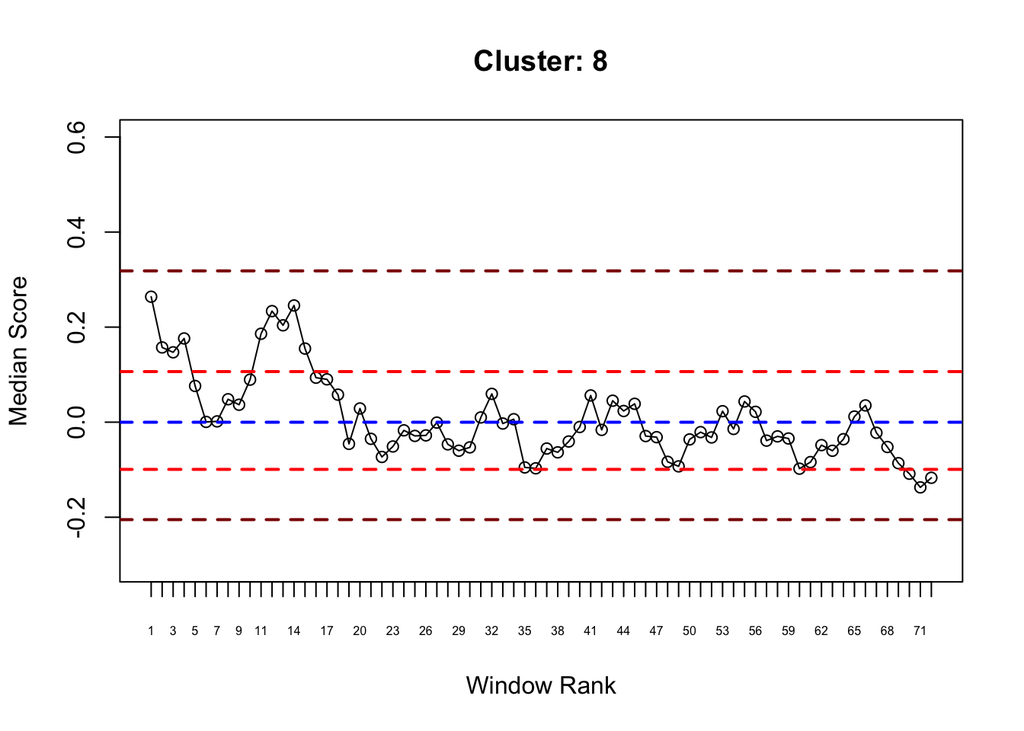

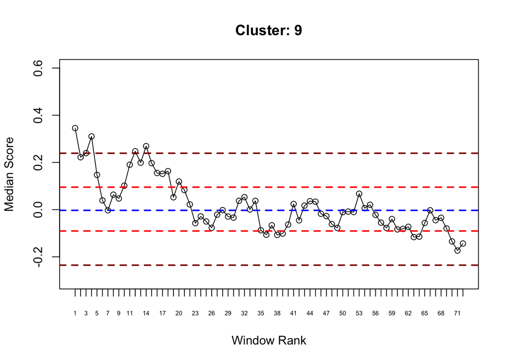

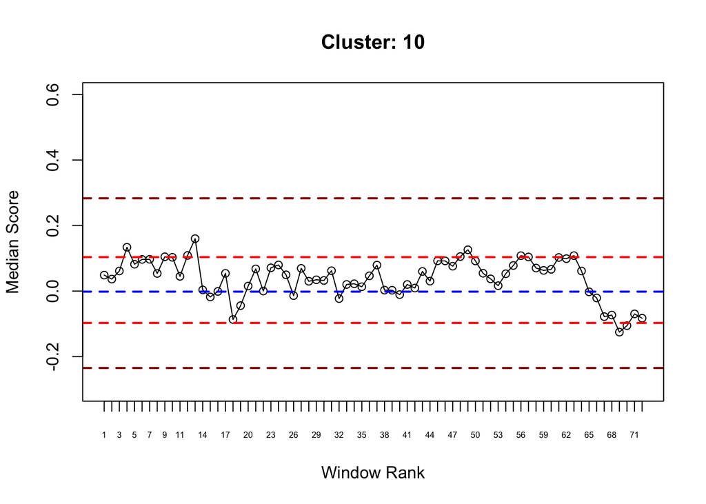

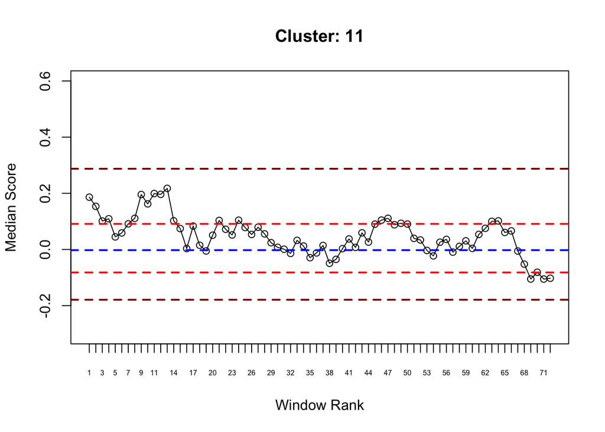

[12 more figures not shown]

```r
rank_plot_for_clusters(
   window_results = window_results.g,
   perm.mat.window = perm.mat.window.data,
   ylim = c(-0.3, 0.6)
 )
```

Subset to select the top ranked genes.

```r
OpenTargets_BIP_Genetic_topGenes_ <- OpenTargets_BIP_Genetic_[1:80]
length(OpenTargets_BIP_Genetic_topGenes_)
```

```
## [1] 80
```

Add the top gene set to a list.

```r
all_gene_sets_OpenTargets_top <- list(OpenTargets_BIP_Genetic_topGenes_=OpenTargets_BIP_Genetic_topGenes_)
```

Calculate the average gene expression in the top gene list and check the percentage of genes present in the Seurat object.

```r
score.mat.top <- matrix(data = NA, nrow = length(all_gene_sets_OpenTargets_top), ncol = 1, dimnames = list(names(all_gene_sets_OpenTargets_top), "% of genes present"))

for (i in 1:length(all_gene_sets_OpenTargets_top)) {
  genes <- unlist(all_gene_sets_OpenTargets_top[i])
  score.mat.top[i] <- mean(genes %in% rownames(se))
  se <- AddModuleScore(se,list(genes), ctrl = 100, name = list(names(all_gene_sets_OpenTargets_top[i])))
}

score.mat.top*100
```

```
##                                   % of genes present
## OpenTargets_BIP_Genetic_topGenes_                100
```

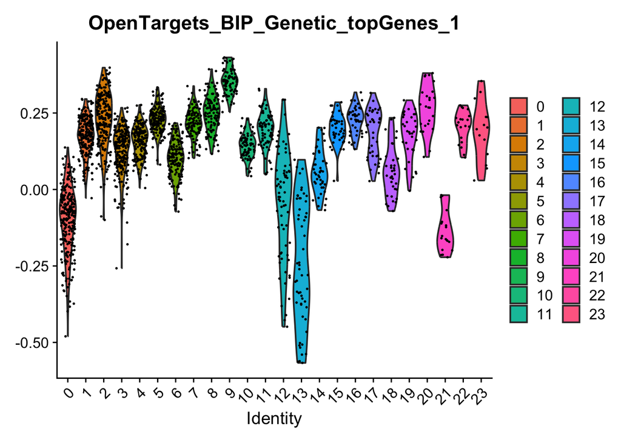

```r
se$cluster_anno_plot <- factor(
  se$cluster_anno,
  levels = as.character(0:23)
)

se <- SetIdent(se, value = "cluster_anno_plot")
p_metaspots <- VlnPlot(se, features = "OpenTargets_BIP_Genetic_topGenes_1",alpha = 1)
p_metaspots
```

# 5 DEGs and Fisher’s exact test

```r
DefaultAssay(se) <- "RNA"
se
```

```
## An object of class Seurat
## 32164 features across 2232 samples within 2 assays
## Active assay: RNA (16082 features, 0 variable features)
##  1 layer present: counts
##  1 other assay present: SCT
```

```r
se <- se %>%
  NormalizeData() %>%
  ScaleData()
```

```
## Normalizing layer: counts
```

```r
se
```

```
## An object of class Seurat
## 32164 features across 2232 samples within 2 assays
## Active assay: RNA (16082 features, 0 variable features)
##  3 layers present: counts, data, scale.data
##  1 other assay present: SCT
```

```r
se <- SetIdent(se, value = "cluster_anno")


DEG_genes_all_tested <- FindAllMarkers(se, only.pos = TRUE, min.pct = 0.25, logfc.threshold = 0.25,slot = "data", return.thresh = 1)
DEG_genes <- subset(DEG_genes_all_tested, subset = p_val_adj <= 0.05) # using only significant DEG
```

Save DEG results.

```r
write.table(DEG_genes_all_tested,file="data/Visium_HD_mouse_coronal/DEG_genes_all_tested_MetaSpots_BIP.csv", col.names = T, row.names = F,quote = FALSE,sep = ";")

saveRDS(DEG_genes_all_tested, file="data/Visium_HD_mouse_coronal/DEG_genes_all_tested_MetaSpots_BIP.rds")
```

Subset to select the top ranked genes.

```r
OpenTargets_BIP_Genetic_top <- OpenTargets_BIP_Genetic_[1:80]
length(OpenTargets_BIP_Genetic_top)
```

```
## [1] 80
```

Run Fisher’s exact test.

```r
fisher_results <- run_fisher_test_degs(se, DEG_genes = DEG_genes, OT_genes = OpenTargets_BIP_Genetic_top)
fisher_results
```

```
##    cluster  A    B  C     D    prop_DEG prop_background odds_ratio    log2_OR
## 1        0 12 2780 68 13222 0.004297994     0.005116629  0.8393236 -0.2527010
## 2        1 22 2004 58 13998 0.010858835     0.004126352  2.6492699  1.4055948
## 3       10 20 2068 60 13934 0.009578544     0.004287552  2.2458214  1.1672432
## 4       11 16 1777 64 14225 0.008923592     0.004478970  2.0011937  1.0008608
## 5       12 12 2984 68 13018 0.004005340     0.005196393  0.7698839 -0.3772872
## 6       13 10 3681 70 12321 0.002709293     0.005649262  0.4782078 -1.0642905
## 7       14 20 2433 60 13569 0.008153282     0.004402377  1.8589004  0.8944495
## 8       15 14 1084 66 14918 0.012750455     0.004404698  2.9189012  1.5454254
## 9       16 20 1566 60 14436 0.012610340     0.004139073  3.0722571  1.6192989
## 10      17 14  993 66 15009 0.013902681     0.004378109  3.2057730  1.6806723
## 11      18 11 1079 69 14923 0.010091743     0.004602455  2.2046866  1.1405736
## 12      19  4  862 76 15140 0.004618938     0.004994742  0.9244142 -0.1133886
## 13       2 17 1229 63 14773 0.013643660     0.004246428  3.2431928  1.6974148
## 14      20 10  855 70 15147 0.011560694     0.004600118  2.5305742  1.3394648
```

[output cut: 35 more lines]

Plot results.

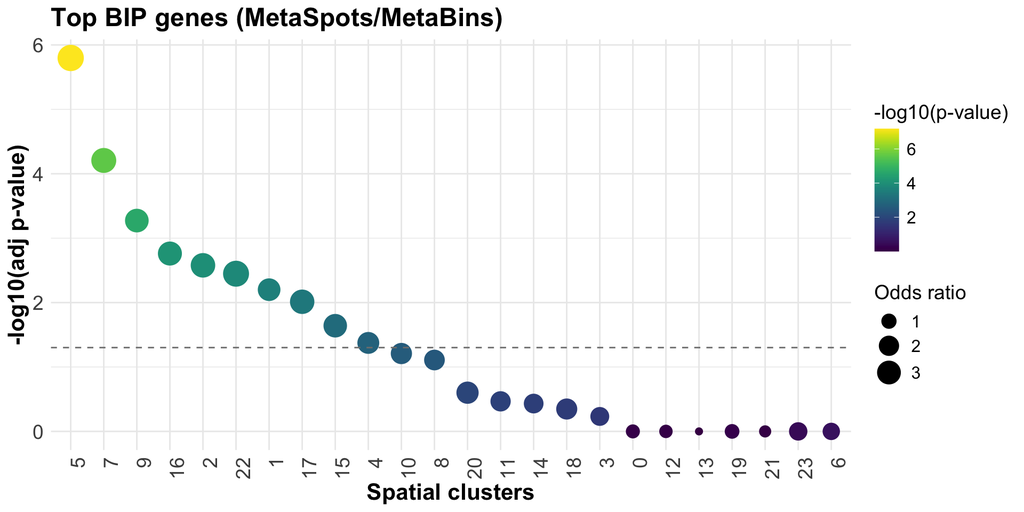

```r
# Ensure clusters are ordered by significance
fisher_results$cluster <- factor(fisher_results$cluster,
                                 levels = fisher_results$cluster[order(fisher_results$adj_p_value)])

# Create the updated plot with viridis scale
p1 <- ggplot(fisher_results, aes(x = cluster, color = -log10(p_value), y = -log10(adj_p_value), size = odds_ratio)) +
  geom_point() +
  geom_hline(yintercept = -log10(0.05), linetype = "dashed", color = "gray50") +
  scale_color_viridis(option = "D", direction = 1, name = "-log10(p-value)") +  # Use Viridis color scale
  scale_size_continuous(range = c(2, 8), name = "Odds ratio") +
  theme_minimal() +
  theme(axis.text.x = element_text(angle = 90, hjust = 1,size = 14),axis.text.y = element_text(size = 14),axis.title.x = element_text(size = 16, face = "bold"),axis.title.y = element_text(size = 16, face = "bold"),plot.title = element_text(size = 18, face = "bold"),legend.title = element_text(size = 14),legend.text = element_text(size = 12)) +
  labs(title = "Top BIP genes (MetaSpots/MetaBins)",
       x = "Spatial clusters",
       y = "-log10(adj p-value)") +
  guides(color = guide_colorbar(order = 1), size = guide_legend(order = 2))

p1
```

Save

```r
pdf("data/Visium_HD_mouse_coronal/spatial_enrichment_topGenes_BIP_dotplot.pdf")

p1

dev.off()
```

```r
fisher_results_save <- fisher_results[
  order(as.numeric(as.character(fisher_results$cluster))),
]

fisher_results_save
```

```
##    cluster  A    B  C     D    prop_DEG prop_background odds_ratio    log2_OR
## 1        0 12 2780 68 13222 0.004297994     0.005116629  0.8393236 -0.2527010
## 2        1 22 2004 58 13998 0.010858835     0.004126352  2.6492699  1.4055948
## 13       2 17 1229 63 14773 0.013643660     0.004246428  3.2431928  1.6974148
## 18       3 26 3580 54 12422 0.007210205     0.004328310  1.6705968  0.7403636
## 19       4 18 1710 62 14292 0.010416667     0.004319353  2.4262044  1.2787011
## 20       5 30 2148 50 13854 0.013774105     0.003596087  3.8697638  1.9522455
## 21       6  8 1211 72 14791 0.006562756     0.004844244  1.3570600  0.4404845
## 22       7 26 1991 54 14011 0.012890431     0.003839317  3.3877290  1.7603185
## 23       8 23 2578 57 13424 0.008842753     0.004228173  2.1010342  1.0710997
## 24       9 26 2242 54 13760 0.011463845     0.003909078  2.9547536  1.5630378
## 3       10 20 2068 60 13934 0.009578544     0.004287552  2.2458214  1.1672432
## 4       11 16 1777 64 14225 0.008923592     0.004478970  2.0011937  1.0008608
## 5       12 12 2984 68 13018 0.004005340     0.005196393  0.7698839 -0.3772872
## 6       13 10 3681 70 12321 0.002709293     0.005649262  0.4782078 -1.0642905
```

[output cut: 35 more lines]

Save

```r
write_csv(fisher_results_save, file = "data/Visium_HD_mouse_coronal/fisher_test_BIP_topGenes.csv")
```

# 6 Plot spatial enrichments

Load spatial dataset.

```r
se_plot <- readRDS(file = "data/Visium_HD_mouse_coronal/mouse_coronal_HD_016um_filtered.rds")
se_plot
```

```
## An object of class Seurat
## 16082 features across 113024 samples within 1 assay
## Active assay: Spatial.016um (16082 features, 0 variable features)
##  1 layer present: counts
##  1 spatial field of view present: slice1.016um
```

Load spatial clusters.

```r
se_spatial_clusters <- readRDS(file = "data/Visium_HD_mouse_coronal/mouse_coronal_HD_016um_spatial_clusters.rds")
head(se_spatial_clusters)
```

```
##                       seurat_cluster.016um
## s_016um_00107_00066-1                    3
## s_016um_00126_00213-1                   14
## s_016um_00158_00414-1                   12
## s_016um_00242_00130-1                    2
## s_016um_00230_00364-1                    4
## s_016um_00329_00125-1                    9
```

Add spatial clusters to metadata.

```r
se_plot$seurat_cluster.016um <- se_spatial_clusters$seurat_cluster.016um
head(se_plot[[]])
```

```
##                       orig.ident nCount_Spatial.016um nFeature_Spatial.016um
## s_016um_00107_00066-1          s                 1853                   1393
## s_016um_00126_00213-1          s                 5794                   3208
## s_016um_00158_00414-1          s                 3739                   2328
## s_016um_00242_00130-1          s                 2547                   1678
## s_016um_00230_00364-1          s                 5021                   2771
## s_016um_00329_00125-1          s                 3945                   2259
##                       seurat_cluster.016um
## s_016um_00107_00066-1                    3
## s_016um_00126_00213-1                   14
## s_016um_00158_00414-1                   12
## s_016um_00242_00130-1                    2
## s_016um_00230_00364-1                    4
## s_016um_00329_00125-1                    9
```

Plot spatial clusters.

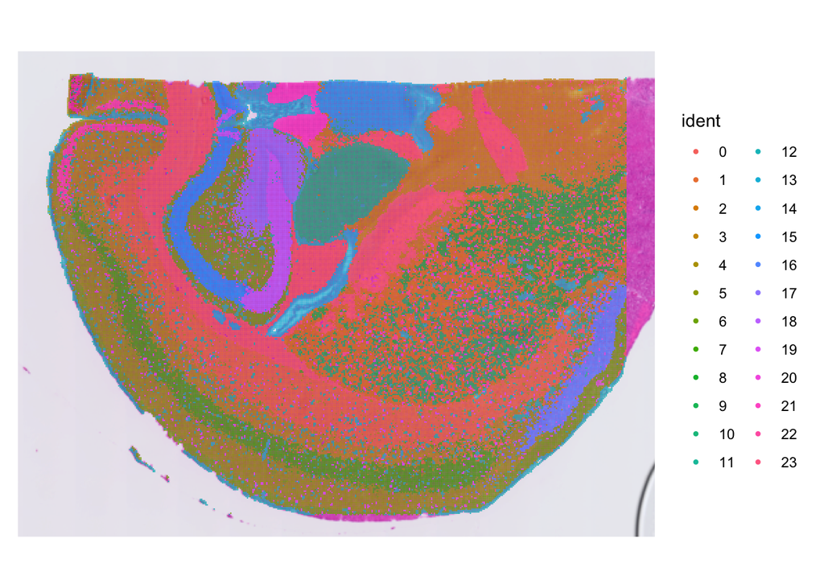

```r
se_plot <- SetIdent(se_plot, value = "seurat_cluster.016um")
SpatialDimPlot(se_plot)
```

Plot the top two enriched spatial clusters.

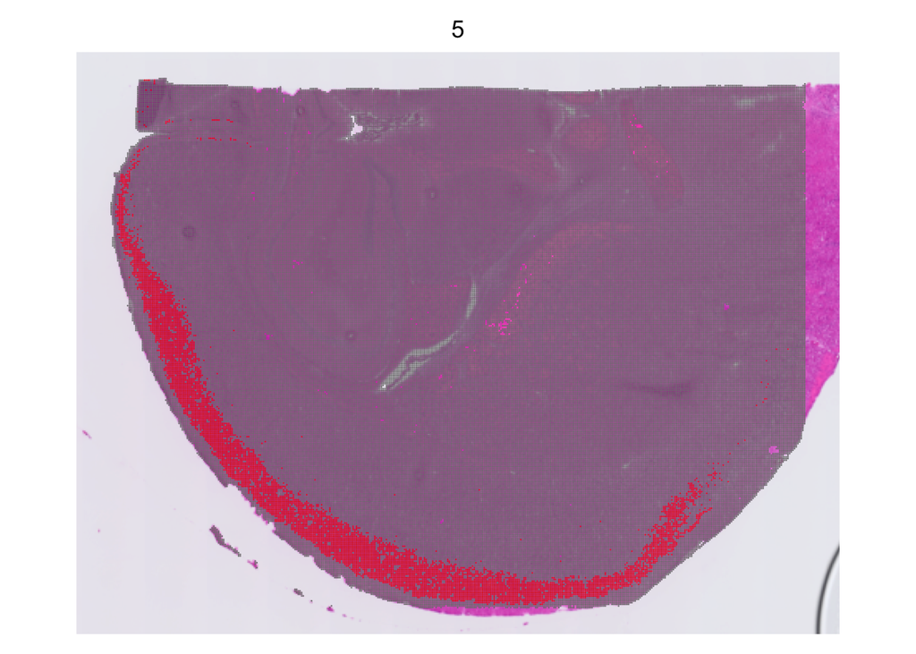

```r
SpatialDimPlot(se_plot, cells.highlight = CellsByIdentities(object = se_plot, idents = c(5)), facet.highlight = TRUE, ncol = 1)
```

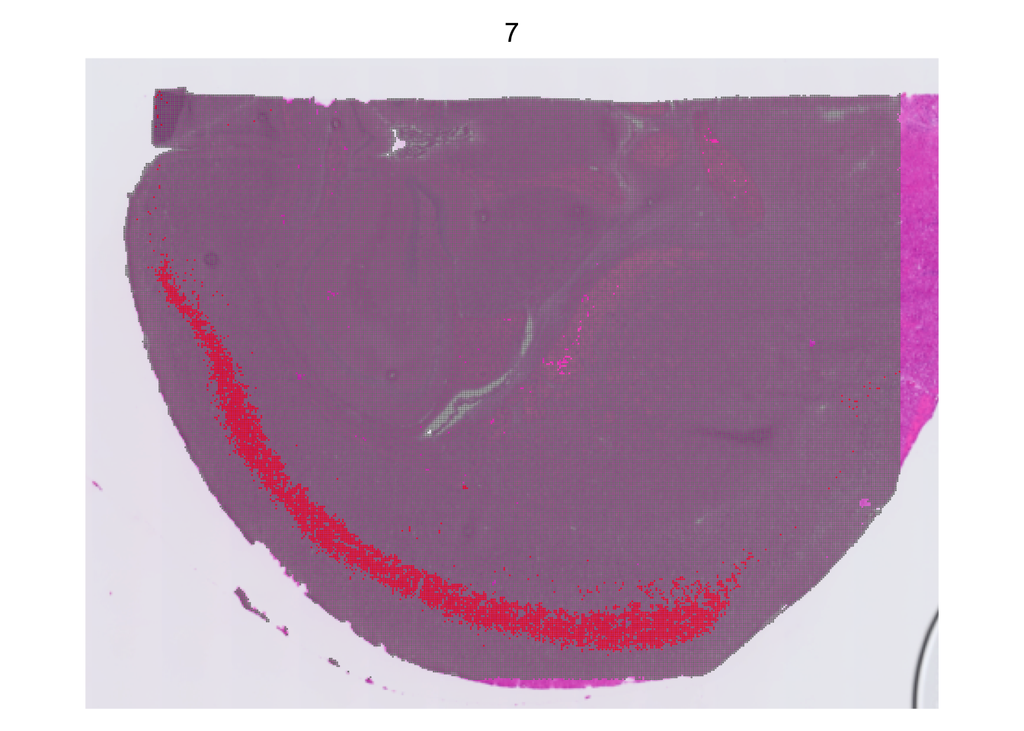

```r
SpatialDimPlot(se_plot, cells.highlight = CellsByIdentities(object = se_plot, idents = c(7)), facet.highlight = TRUE, ncol = 1)
```

Add the enrichment results to the Seurat object’s metadata.

```r
# Ensure cluster column is character or factor
fisher_results$cluster <- as.character(fisher_results$cluster)

# Create a data frame for metadata mapping
meta_to_add <- fisher_results[, c("cluster", "p_value", "odds_ratio", "adj_p_value")]

# Map metadata to each spot/bin in the Seurat object
cluster_ids <- as.character(se_plot$seurat_cluster.016um)
meta_matched <- meta_to_add[match(cluster_ids, meta_to_add$cluster), -1]

# Add the metadata columns to the Seurat object
se_plot$p_value_fisher <- meta_matched$p_value
se_plot$odds_ratio_fisher <- meta_matched$odds_ratio
se_plot$adj_p_value_fisher <- meta_matched$adj_p_value

# Compute -log10(p_value) and add as metadata
se_plot$neg.log.10.p_value_fisher <- -log10(meta_matched$p_value)
se_plot$neg.log.10.adj_p_value_fisher <- -log10(meta_matched$adj_p_value)
```

Plot the adjusted p-values (with HE).

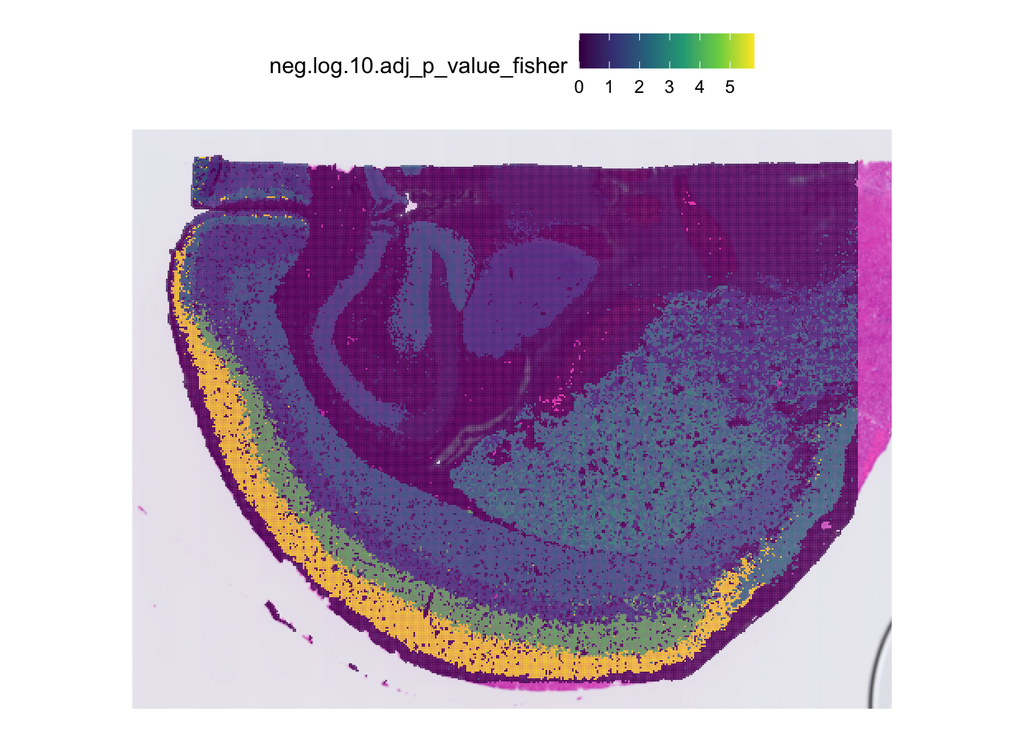

```r
p2 <- SpatialFeaturePlot(se_plot,features = "neg.log.10.adj_p_value_fisher") + scale_fill_viridis_c()
p2
```

Plot the adjusted p-values (without HE).

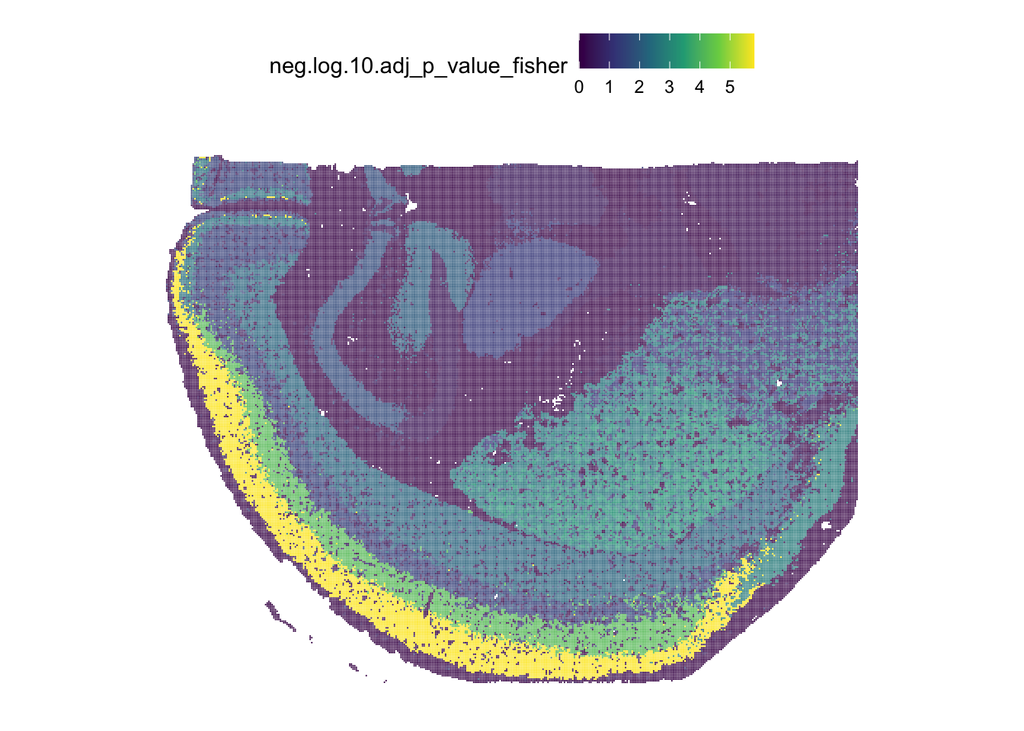

```r
p3 <- SpatialFeaturePlot(se_plot,features = "neg.log.10.adj_p_value_fisher", image.alpha = 0) + scale_fill_viridis_c()
p3
```